# Haemoglobin concentration in Peruvian children aged 6-59 months

Dataset 6: Peru DHS child anaemia and growth extract

RSR feasibility analysis

2026-08-03

# Introduction

The Peruvian Demographic and Health Survey (ENDES) measures altitude-adjusted haemoglobin in every surveyed child aged 6-59 months, alongside detailed household, maternal and geographic information. Childhood anaemia remains one of Peru’s most persistent public-health problems: roughly a third of preschool children in this extract fall below the 11 g/dL threshold, with a strong socio-economic and regional patterning that has been described in DHS-based analyses of ENDES (for example Gonzales and colleagues’ work on anaemia and altitude in Peruvian children). Haemoglobin is analysed here on its continuous scale rather than dichotomised, which preserves information and avoids the loss of power that comes with cut-points.

**Aim.** Among Peruvian children aged 6-59 months, we examined which of child age, child sex, natural region, household wealth, maternal education and maternal indigenous identity are independently associated with altitude-adjusted haemoglobin concentration, mutually adjusting for the others.

This is a *Purpose 3* analysis: several predictors are of interest and the question is which remain associated with the outcome after mutual adjustment.

# Methods

**Data source.** A cross-sectional extract of 19191 children aged 6-59 months from the Peru Demographic and Health Survey (ENDES), a nationally implemented household survey. Each row is one child with a valid altitude-adjusted haemoglobin measurement, linked to their mother’s interview and to household characteristics.

**Variables.** The outcome is `haemoglobin_g_dl`, altitude-adjusted haemoglobin in g/dL, measured by HemoCue on a capillary blood sample. Predictors are child age in months (continuous, 6-59); child sex (reference *Female*); natural region of Peru (reference *Lima metropolitan*, the lowest-altitude and best-resourced region, versus rest of coast, highlands and jungle); household wealth quintile (reference *Poorest*); mother’s highest education (reference *Primary or none*); and whether the mother belongs to an indigenous ethnic group (reference *No*). These six were chosen in advance because they capture the three routes by which haemoglobin varies in this age group: biological maturation (age, sex), geography and altitude-related erythropoiesis (region), and household socio-economic position (wealth, education, ethnicity).

**Statistical analysis.** Linear regression via `lm()`, justified because the outcome is continuous and approximately symmetric. We fitted a univariable model for each predictor first, then a single multivariable model containing all of them. Predictors were chosen in advance on subject-matter grounds, not by significance. Significance threshold 0.05; estimates are reported with 95% confidence intervals. Assumptions were checked with `performance::check_model()`. Analysis used R version 4.6.0 (2026-04-24) with tidyverse, gtsummary and performance.

**Missing data.** Complete-case analysis: 19191 of 19191 rows were analysed (0 dropped). All six predictors and the outcome are complete in this extract, so listwise deletion removes no rows at all and selection bias from missingness is not a concern for this particular model.

# Results

## Sample characteristics

**Table 1. Sample characteristics.**

| **Characteristic** | **N** | **N = 19,191**<sup>1</sup> |
| --- | --- | --- |
| Haemoglobin (g/dL) | 19,191 | 11.30 (10.60, 12.00) |
| Child age (months) | 19,191 | 33 (19, 46) |
| Child sex | 19,191 |  |
| Female |  | 9,268 (48%) |
| Male |  | 9,923 (52%) |
| Natural region | 19,191 |  |
| Lima metropolitan |  | 2,310 (12%) |
| Rest of coast |  | 5,504 (29%) |
| Highlands |  | 6,383 (33%) |
| Jungle |  | 4,994 (26%) |
| Household wealth quintile | 19,191 |  |
| Poorest |  | 5,993 (31%) |
| Poorer |  | 5,175 (27%) |
| Middle |  | 3,778 (20%) |
| Richer |  | 2,593 (14%) |
| Richest |  | 1,652 (8.6%) |
| Mother's education | 19,191 |  |
| Primary or none |  | 3,631 (19%) |
| Secondary |  | 9,514 (50%) |
| Higher |  | 6,046 (32%) |
| Mother indigenous | 19,191 | 2,012 (10%) |

<sup>1</sup> Median (Q1, Q3); n (%)

Median haemoglobin was 11.3 g/dL (IQR 10.6 to 12), which sits only marginally above the 11 g/dL anaemia threshold, so a large share of this sample is close to or below the cut-point. The sample is weighted towards the poorer end of the wealth distribution (31.2% in the poorest quintile) and towards the highlands (33.3%), reflecting the DHS design which oversamples rural and less-populated departments.

## Exploratory figure

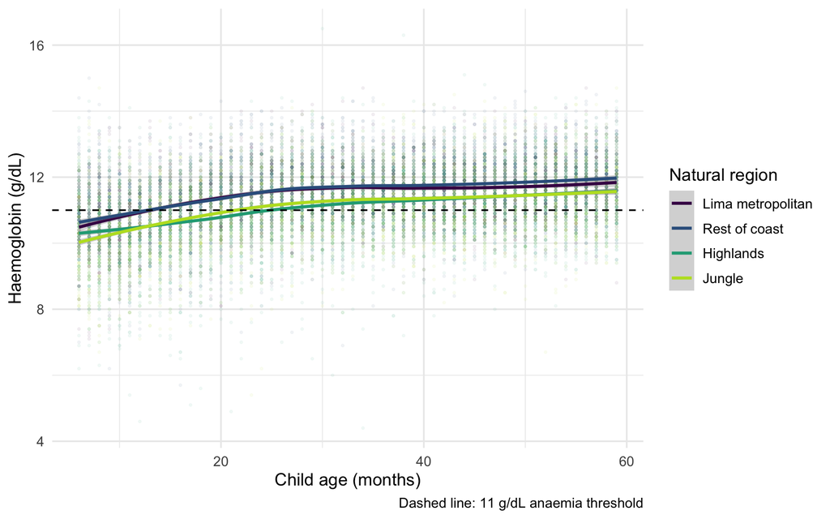

Figure 1. Haemoglobin against child age, by natural region, with LOESS smoothers.

Haemoglobin rises steeply across the second year of life and then flattens after about 24 months in every region, and the four regional curves are separated by roughly 0.4 g/dL across the whole age range, with the highlands and jungle sitting below Lima and the rest of the coast.

## Univariable models

| **Characteristic** | **N** | **Beta** | **95% CI** | **p-value** |
| --- | --- | --- | --- | --- |
| Child age (months) | 19,191 | 0.02 | 0.02, 0.02 | <0.001 |
| Child sex | 19,191 |  |  |  |
| Female |  | — | — |  |
| Male |  | -0.03 | -0.07, 0.00 | 0.029 |
| Natural region | 19,191 |  |  |  |
| Lima metropolitan |  | — | — |  |
| Rest of coast |  | 0.08 | 0.03, 0.13 | 0.003 |
| Highlands |  | -0.40 | -0.45, -0.34 | <0.001 |
| Jungle |  | -0.38 | -0.43, -0.33 | <0.001 |
| Household wealth quintile | 19,191 |  |  |  |
| Poorest |  | — | — |  |
| Poorer |  | 0.27 | 0.23, 0.31 | <0.001 |
| Middle |  | 0.43 | 0.39, 0.47 | <0.001 |
| Richer |  | 0.59 | 0.54, 0.64 | <0.001 |
| Richest |  | 0.72 | 0.66, 0.78 | <0.001 |
| Mother's education | 19,191 |  |  |  |
| Primary or none |  | — | — |  |
| Secondary |  | 0.08 | 0.04, 0.13 | <0.001 |
| Higher |  | 0.37 | 0.33, 0.42 | <0.001 |
| Mother indigenous | 19,191 |  |  |  |
| No |  | — | — |  |
| Yes |  | -0.45 | -0.50, -0.39 | <0.001 |

Abbreviation: CI = Confidence Interval

Child age is the strongest single predictor: each additional month of age is associated with a 0.0238 g/dL higher haemoglobin (95% CI 0.0228 to 0.0247, p < 0.001), which over the 53-month span of the sample amounts to about 1.26 g/dL between the youngest and oldest children – clinically the single largest contrast in the table. All other predictors also reach significance in crude models, which is unsurprising at this sample size and is a reason to read the effect sizes rather than the p-values.

## Why adjustment is needed

The crude regional and ethnic contrasts are almost certainly confounded by household socio-economic position and by child age. **Household wealth** is associated with region – the highlands and jungle contain almost no children in the richest quintile whereas Lima contains almost no children in the poorest – and wealth is independently associated with haemoglobin through diet quality, access to iron supplementation and infection burden; so part of any raw “highlands effect” is really a poverty effect. **Child age** confounds the socio-economic contrasts in the opposite direction: haemoglobin climbs sharply with age in this window, and the age distribution is not identical across wealth quintiles or regions, so a crude comparison between, say, indigenous and non-indigenous mothers partly compares younger children with older ones. **Maternal education** plays the same role for the indigenous contrast: indigenous mothers in this extract have systematically less schooling, and schooling predicts feeding practice and health-service use, so an unadjusted indigenous coefficient absorbs the education effect. Mutual adjustment separates these overlapping gradients.

## Multivariable model

| **Characteristic** | **Beta** | **95% CI** | **p-value** |
| --- | --- | --- | --- |
| Child age (months) | 0.02 | 0.02, 0.02 | <0.001 |
| Child sex |  |  |  |
| Female | — | — |  |
| Male | -0.03 | -0.06, 0.00 | 0.024 |
| Natural region |  |  |  |
| Lima metropolitan | — | — |  |
| Rest of coast | 0.14 | 0.09, 0.19 | <0.001 |
| Highlands | -0.18 | -0.24, -0.13 | <0.001 |
| Jungle | -0.16 | -0.21, -0.11 | <0.001 |
| Household wealth quintile |  |  |  |
| Poorest | — | — |  |
| Poorer | 0.13 | 0.09, 0.17 | <0.001 |
| Middle | 0.21 | 0.17, 0.26 | <0.001 |
| Richer | 0.34 | 0.28, 0.40 | <0.001 |
| Richest | 0.43 | 0.36, 0.50 | <0.001 |
| Mother's education |  |  |  |
| Primary or none | — | — |  |
| Secondary | -0.03 | -0.07, 0.01 | 0.13 |
| Higher | 0.08 | 0.03, 0.13 | 0.002 |
| Mother indigenous |  |  |  |
| No | — | — |  |
| Yes | -0.14 | -0.19, -0.09 | <0.001 |

Abbreviation: CI = Confidence Interval

Model fit

| Statistic | Value |
| --- | --- |
| R-squared | 0.178 |
| Adjusted R-squared | 0.177 |
| Residual SD (g/dL) | 0.997 |
| Observations | 19191.000 |
| Model parameters | 13.000 |

The model explains 17.8% of the variance in haemoglobin (adjusted R-squared 0.177), so the great majority of between-child variation is left unexplained by these six characteristics. Conditional on the other five predictors, each additional month of age is associated with a 0.0233 g/dL higher haemoglobin (95% CI 0.0224 to 0.0242); children in the jungle average -0.16 g/dL relative to Lima (95% CI -0.21 to -0.11); and children in the richest quintile average 0.43 g/dL compared with the poorest (95% CI 0.36 to 0.5). Boys average -0.033 g/dL relative to girls, a difference that only just clears p = 0.05 and is far too small to matter clinically.

## Unadjusted versus adjusted

**Table 2. Unadjusted and adjusted estimates.**

| **Characteristic** | **Unadjusted** **N** | **Unadjusted** **Beta** | **Unadjusted** **95% CI** | **Unadjusted** **p-value** | **Adjusted** **Beta** | **Adjusted** **95% CI** | **Adjusted** **p-value** |
| --- | --- | --- | --- | --- | --- | --- | --- |
| Child age (months) | 19,191 | 0.02 | 0.02, 0.02 | <0.001 | 0.02 | 0.02, 0.02 | <0.001 |
| Child sex | 19,191 |  |  |  |  |  |  |
| Female |  | — | — |  | — | — |  |
| Male |  | -0.03 | -0.07, 0.00 | 0.029 | -0.03 | -0.06, 0.00 | 0.024 |
| Natural region | 19,191 |  |  |  |  |  |  |
| Lima metropolitan |  | — | — |  | — | — |  |
| Rest of coast |  | 0.08 | 0.03, 0.13 | 0.003 | 0.14 | 0.09, 0.19 | <0.001 |
| Highlands |  | -0.40 | -0.45, -0.34 | <0.001 | -0.18 | -0.24, -0.13 | <0.001 |
| Jungle |  | -0.38 | -0.43, -0.33 | <0.001 | -0.16 | -0.21, -0.11 | <0.001 |
| Household wealth quintile | 19,191 |  |  |  |  |  |  |
| Poorest |  | — | — |  | — | — |  |
| Poorer |  | 0.27 | 0.23, 0.31 | <0.001 | 0.13 | 0.09, 0.17 | <0.001 |
| Middle |  | 0.43 | 0.39, 0.47 | <0.001 | 0.21 | 0.17, 0.26 | <0.001 |
| Richer |  | 0.59 | 0.54, 0.64 | <0.001 | 0.34 | 0.28, 0.40 | <0.001 |
| Richest |  | 0.72 | 0.66, 0.78 | <0.001 | 0.43 | 0.36, 0.50 | <0.001 |
| Mother's education | 19,191 |  |  |  |  |  |  |
| Primary or none |  | — | — |  | — | — |  |
| Secondary |  | 0.08 | 0.04, 0.13 | <0.001 | -0.03 | -0.07, 0.01 | 0.13 |
| Higher |  | 0.37 | 0.33, 0.42 | <0.001 | 0.08 | 0.03, 0.13 | 0.002 |
| Mother indigenous | 19,191 |  |  |  |  |  |  |
| No |  | — | — |  | — | — |  |
| Yes |  | -0.45 | -0.50, -0.39 | <0.001 | -0.14 | -0.19, -0.09 | <0.001 |

Abbreviation: CI = Confidence Interval

## Diagnostics

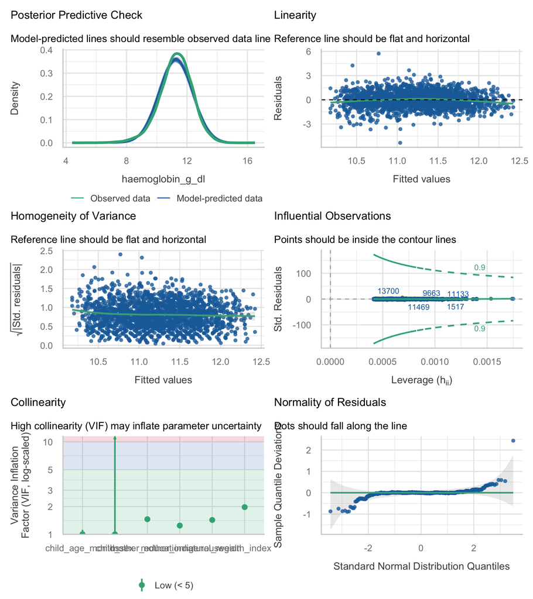

The **posterior-predictive check** and **linearity** panel show the fitted model tracking the observed haemoglobin distribution well, with only a mild under-prediction in the upper tail. The **homogeneity of variance** panel is close to flat, so constant residual variance is a defensible assumption. The **collinearity** panel is entirely in the low range (maximum VIF 1.97), so the wealth, region and education coefficients can be interpreted separately despite their correlation. **Influential observations**: no point approaches Cook’s distance thresholds, which is expected with 19191 observations. The **normality of residuals** panel shows mild departure in the tails only; with a sample this large the central limit theorem makes the coefficient standard errors robust to that. The most substantive diagnostic problem is not visible in these panels at all: the LOESS curves in Figure 1 show haemoglobin rising steeply then plateauing with age, so a single linear age term is a simplification and a spline or quadratic term would fit better.

# Discussion

**Limitations.** This is a cross-sectional survey, so all estimates are associations and not causal effects; a child’s haemoglobin today reflects diet, infection and supplementation history that this extract does not measure at all (iron supplementation, recent fever or diarrhoea, dietary diversity, maternal anaemia). The source ENDES analysis used the DHS complex design – cluster (HV001), stratum (HV022) and sampling weights – whereas this extract contains only the weight variable and it is deliberately not used here; consequently the standard errors are too narrow, the estimates are not design-corrected, and **this sample must not be described as nationally representative**. With 19191 rows almost every comparison is statistically significant, so conclusions should lead with effect sizes: a sex difference of -0.033 g/dL is clinically meaningless whatever its p-value. Haemoglobin was measured by capillary HemoCue, which is noisier than venous laboratory measurement, and the altitude adjustment is a formula rather than a measured correction, so residual altitude confounding may persist inside the highlands category. The linear age term understates the curvature visible in Figure 1. Finally, wealth, region, education and ethnicity are strongly intertwined in Peru, and although VIFs are acceptable, the mutually adjusted coefficients should be read as “holding the others fixed”, a contrast that is partly hypothetical for combinations that barely exist (there are almost no richest-quintile jungle households).

**Future work.** Refit with the DHS survey design and a spline for age, and add maternal haemoglobin and supplementation history if the fuller ENDES recode file can be obtained.

# Feasibility notes

*Not part of a student report.*

- **Works well.** This is the cleanest of the five outcomes in this dataset. Complete data on outcome and all six predictors (0 rows dropped), a symmetric continuous outcome, no collinearity problems (max VIF 1.97), and a genuinely interesting Purpose 3 story with confounding that actually moves estimates.
- **Deterministic-twin trap.** `anaemia` is exactly `haemoglobin_g_dl < 11` and must never appear as a predictor here. `stunting`/`height_for_age_z` are also co-outcomes of undernutrition rather than exposures and were excluded on those grounds, not for statistical reasons.
- **Low R-squared.** Adjusted R-squared is only 0.177. Students who expect a “good model” will be disappointed; this needs framing in advance as normal for individual-level biomarker data.
- **Non-linear age.** A single linear term for `child_age_months` visibly misfits (steep rise then plateau). This is a *teaching opportunity* rather than a defect, but a student who never plots the smoother will miss it.
- **Sample size.** At 19191 rows everything is significant. The brief must force effect-size-led interpretation or students will simply list stars.
- **Design not honoured.** Only the weight is present, not cluster or stratum, so a correct survey analysis is impossible from this extract. This is fine for a course exercise provided the limitation is stated.